# PML Prediction Assignment

Hussain Shaik

August 2018

## Do you even lift, correctly?

This project is a peer-graded assignment in the course *Practical Machine Learning*, part of the *Data Science* Specialization on Coursera from the Johns Hopkins University.

### Summary

In this project, we will use data from accelerometers on the belt, forearm, arm, and dumbell of 6 participants, who were asked to perform barbell lifts correctly and incorrectly in 5 different ways. Our goal is to build a machine learning model that accurately predicts the good (“A”) and the bad ways (“B”,“C”,“D”,“E”) based on the sensory data. We will see that a random forrest model is able to do so.

### Reading and preparing the data

Data source: Velloso, E.; Bulling, A.; Gellersen, H.; Ugulino, W.; Fuks, H. “Qualitative Activity Recognition of Weight Lifting Exercises. Proceedings of 4th International Conference in Cooperation with SIGCHI (Augmented Human ’13)”. Stuttgart, Germany: ACM SIGCHI, 2013.

The authors are kind enough to let us use their data for assignments like this.

More information is available from this [website](http://groupware.les.inf.puc-rio.br/har) (see the section on the Weight Lifting Exercise Dataset).

```r
## Setting working directory for project
setwd("C:/Users/Steffen/Desktop/Coursera/Data Science/8. Machine Learning")
## Loading required packages
library(caret)
library(dplyr)
library(corrplot)
## Reading the data
train_set <- read.csv("pml-training.csv")
testing <- read.csv("pml-testing.csv")
```

To validate our predictions and improve our model, we use 20% from the training set as a validation set.

```r
## Creating training and validation set
inTrain <- createDataPartition(y = train_set$classe, p = .8, list = FALSE)
training <- train_set[inTrain,]
validation <- train_set[-inTrain,]
dim(training)
```

```
## [1] 15699   160
```

```r
dim(validation)
```

```
## [1] 3923  160
```

### The “num_window” variable

```r
str(training[,1:8])
```

```
## 'data.frame':    15699 obs. of  8 variables:
##  $ X                   : int  1 3 4 5 6 7 8 11 12 13 ...
##  $ user_name           : Factor w/ 6 levels "adelmo","carlitos",..: 2 2 2 2 2 2 2 2 2 2 ...
##  $ raw_timestamp_part_1: int  1323084231 1323084231 1323084232 1323084232 1323084232 1323084232 1323084232 1323084232 1323084232 1323084232 ...
##  $ raw_timestamp_part_2: int  788290 820366 120339 196328 304277 368296 440390 500302 528316 560359 ...
##  $ cvtd_timestamp      : Factor w/ 20 levels "02/12/2011 13:32",..: 9 9 9 9 9 9 9 9 9 9 ...
##  $ new_window          : Factor w/ 2 levels "no","yes": 1 1 1 1 1 1 1 1 1 1 ...
##  $ num_window          : int  11 11 12 12 12 12 12 12 12 12 ...
##  $ roll_belt           : num  1.41 1.42 1.48 1.48 1.45 1.42 1.42 1.45 1.43 1.42 ...
```

At some point, looking for good predictors for our model, we come across the first columns in the training set, which are not sensory data (starting with “roll_belt”), but information about the dataset itself. We can remove the first 6 columns of the training set. But what about the *num_window* variable? It’s an integer, without missing data and NZV doesn’t apply. Including it into our model, however, could be misleading. Here’s why:

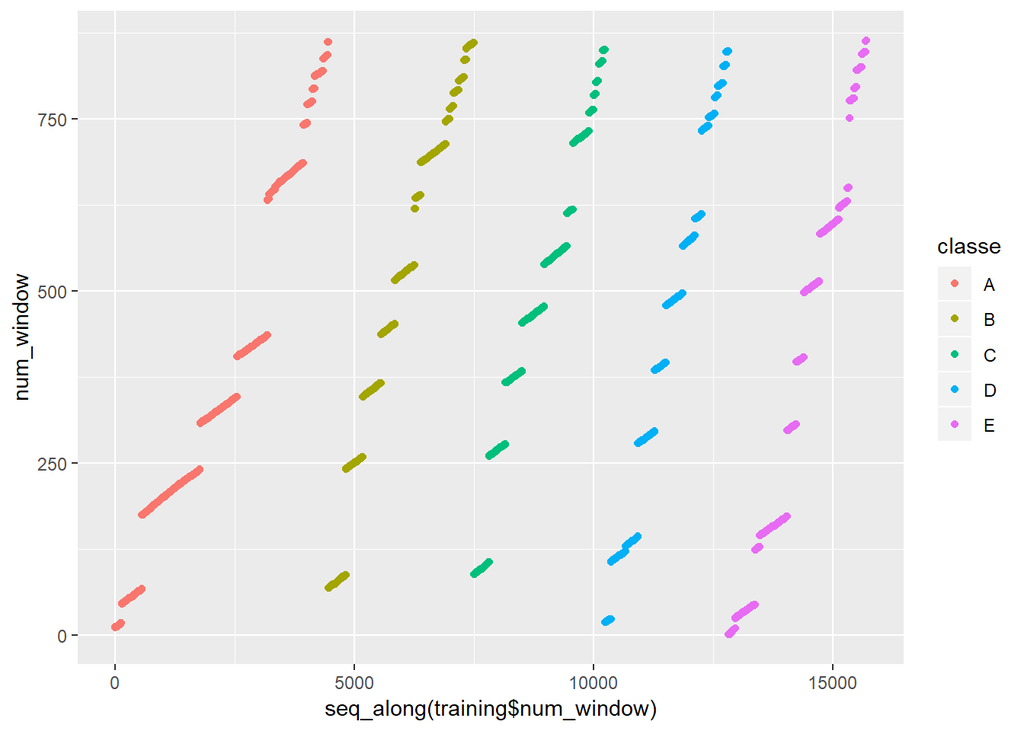

```r
qplot(seq_along(training$num_window), num_window, color = classe, data = training)
```

```r
summary(training$num_window)
```

```
##    Min. 1st Qu.  Median    Mean 3rd Qu.    Max.
##     1.0   219.0   422.0   429.6   644.0   864.0
```

It counts the number of (I assume time-) windows per classe (our outcome variable), but more importantly, it never uses the same numbers to do so, making each group unique.

```r
df_A <- training$num_window[training$classe == "A"]
df_B <- training$num_window[training$classe == "B"]
df_C <- training$num_window[training$classe == "C"]
df_D <- training$num_window[training$classe == "D"]
df_E <- training$num_window[training$classe == "E"]
intersect(df_A, c(df_B, df_C, df_D, df_E))
```

```
## integer(0)
```

A random forrest model picks that up and gives (near) perfect prediction. To shorten processing time, I change the default from bootstrapping 25 times to 5 fold cross validation.

```r
set.seed(232323)
## Setting control parameters
control_num_window <- trainControl(method = "cv", number = 5, verboseIter = FALSE)
## Training the model
model_num_window <- train(classe ~ num_window, data = training, method = "rf",                            trControl = control_num_window)
model_num_window$finalModel
```

```
##
## Call:
##  randomForest(x = x, y = y, mtry = param$mtry)
##                Type of random forest: classification
##                      Number of trees: 500
## No. of variables tried at each split: 1
##
##         OOB estimate of  error rate: 0.01%
## Confusion matrix:
##      A    B    C    D    E  class.error
## A 4464    0    0    0    0 0.0000000000
## B    0 3038    0    0    0 0.0000000000
## C    0    0 2738    0    0 0.0000000000
## D    0    0    0 2573    0 0.0000000000
## E    0    0    0    1 2885 0.0003465003
```

```r
## Predicting on validation set
confusionMatrix(predict(model_num_window, validation), validation$classe)$overall[1]
```

```
##  Accuracy
## 0.9997451
```

Any random forrest model containing the *num_window* variable would automatically have a high accuracy. If your goal is just to predict the test cases, you wouldn’t need any other variable. Actually, every added variable should (even slightly) reduce accuracy. Since the 20 test cases are part of the same dataset and contain the telling *num_window* variable. **!SPOILER ALERT!**

```r
## Predicting the test cases
pred_test <- predict(model_num_window, testing)
pred_test
```

```
##  [1] B A B A A E D B A A B C B A E E A B B B
## Levels: A B C D E
```

But the out of sample error of our model would be turning from hero to zero with an independed dataset, if not recorded in the very same way. The model works on our data, but yields no practical relevance.

### Finding good sensory predictors

```r
training <- training[,-(1:7)]
```

Next we check for missing data in the training set, create a training set without, and check if we can impute missing data when occuring.

```r
## Creating a data frame of all columns with missing data
train_na <- training[, colSums(is.na(training)) > 0]
dim(train_na)
```

```
## [1] 15699    67
```

```r
## Reducing the training set to columns without missing data
training <- training[, colSums(is.na(training)) == 0]
dim(training)
```

```
## [1] 15699    86
```

```r
## Calculating the percentage of missing values
na_percent <- sapply(train_na, function(x) mean(is.na(x)))
table(na_percent)
```

```
## na_percent
## 0.978788457863558
##                67
```

All columns with missing data are missing more than 97% of it. So we leave them be and move on to filter out variables with near zero variance, that wouldn’t help our model.

```r
nzv <- nearZeroVar(training)
training <- training[, -nzv]
dim(training)
```

```
## [1] 15699    53
```

That leaves us with 52 variables we can predict with and our outcome variable *classe*.

```r
validation <- select(validation, names(training))
dim(validation)
```

```
## [1] 3923   53
```

### Fitting Models

Random forrest models seem to be very good at this kind of prediction. Let’s find out. We reduce the number of folds in cross validation to 3 and also have an eye on the time needed for training the model.

```r
## Setting resampling to 3 fold cross validation
control_rf <- trainControl(method = "cv", number = 3, verboseIter = FALSE)
set.seed(242424)
## Starting time
start <- Sys.time()
## Training the random forrest model
model_rf <- train(classe ~ ., data = training, method = "rf", trControl = control_rf)
## Stopping time
finish <- Sys.time()
## Calculating time needed for training model
time_rf <- finish - start
## Showing final model
model_rf$finalModel
```

```
##
## Call:
##  randomForest(x = x, y = y, mtry = param$mtry)
##                Type of random forest: classification
##                      Number of trees: 500
## No. of variables tried at each split: 27
##
##         OOB estimate of  error rate: 0.57%
## Confusion matrix:
##      A    B    C    D    E class.error
## A 4457    5    1    0    1 0.001568100
## B   14 3018    6    0    0 0.006583278
## C    0   14 2714   10    0 0.008765522
## D    0    0   23 2547    3 0.010104936
## E    0    1    4    8 2873 0.004504505
```

```r
## Showing time needed for training
time_rf
```

```
## Time difference of 8.756693 mins
```

```r
## Predicting accuracy for validation set
confusionMatrix(predict(model_rf, validation), validation$classe)$overall[1]
```

```
##  Accuracy
## 0.9936273
```

In comparison, let’s see how a gradient boosting model works with our data.

```r
set.seed(262626)
## Starting time
start <- Sys.time()
## Training the boosting model
model_boo <- train(classe ~ ., data = training, method = "gbm", verbose = F, trControl = control_rf)
## Stopping time
finish <- Sys.time()
## Calculating time needed for training model
time_boo <- finish - start
## Showing time needed for training
time_boo
```

```
## Time difference of 3.878026 mins
```

```r
## Predicting accuracy for validation set
confusionMatrix(predict(model_boo, validation), validation$classe)$overall[1]
```

```
##  Accuracy
## 0.9663523
```

The random forrest model is more accurate, but needs longer preocessing time. Let’s see if we can reduce that time, without losing much of the accuracy.

### Improving the Model

First we can take a look at the variables that are most important for our random forrest model.

```r
imp_rf <- varImp(model_rf, scale = FALSE)
imp_rf
```

```
## rf variable importance
##
##   only 20 most important variables shown (out of 52)
##
##                      Overall
## roll_belt             1628.8
## pitch_forearm          995.8
## yaw_belt               866.4
## pitch_belt             743.1
## roll_forearm           727.3
## magnet_dumbbell_y      716.5
## magnet_dumbbell_z      710.0
## accel_dumbbell_y       400.7
## magnet_dumbbell_x      304.3
## accel_forearm_x        292.7
## roll_dumbbell          281.4
## magnet_belt_z          273.2
## magnet_forearm_z       246.2
## total_accel_dumbbell   245.8
## accel_dumbbell_z       242.2
## accel_belt_z           230.8
## magnet_belt_y          216.6
## yaw_arm                203.2
## gyros_belt_z           201.9
## magnet_belt_x          185.9
```

How much accuracy would we lose reducing the number of variables used to the top 20, and how much faster would it be computed?

```r
## Extracting the names for the top 20 variables
df_imp <- data.frame(imp_rf$importance)
df_imp$names <- row.names(df_imp)
## Creating new training and validation set
train_imp <- select(training, df_imp[order(-df_imp$Overall),][1:20,]$names, classe)
valid_imp <- select(validation, df_imp[order(-df_imp$Overall),][1:20,]$names, classe)
## Running the new model
set.seed(252525)
## Starting time
start <- Sys.time()
## Training model
model_rf_imp20 <- train(classe ~ ., data=train_imp, method="rf", trControl=control_rf)
## Stopping time
finish <- Sys.time()
## Calculating time needed for training model
time_rf_imp20 <- finish - start
## Showing time needed for training
time_rf_imp20
```

```
## Time difference of 2.980154 mins
```

```r
## Predicting accuracy for validation set
confusionMatrix(predict(model_rf_imp20, valid_imp), valid_imp$classe)$overall[1]
```

```
##  Accuracy
## 0.9938822
```

We could also take a look at high correlations among the variables in the model, and might reduce the predictors with principal components analysis.

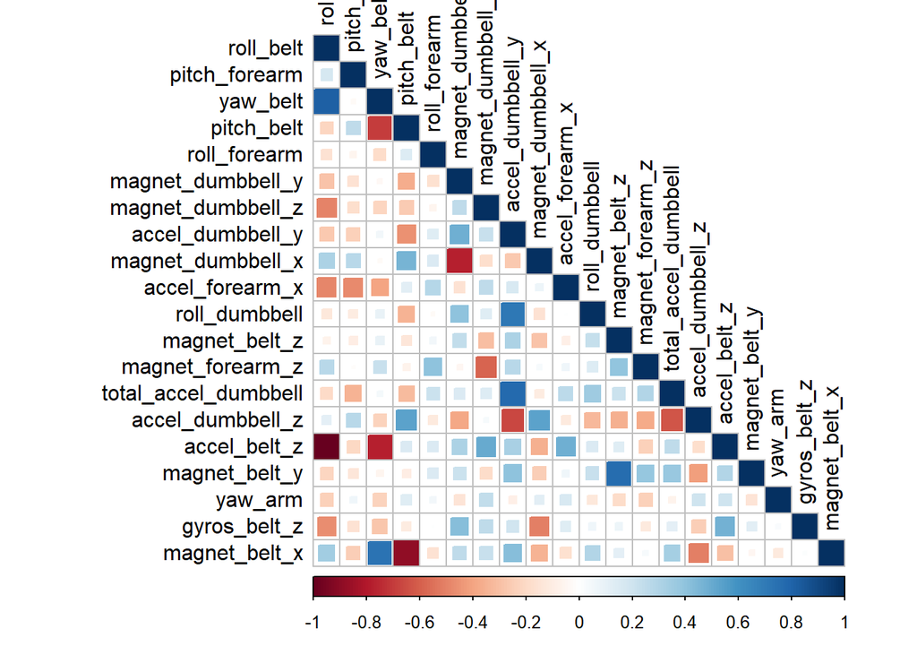

```r
## Creating correlation matrix without the outcome variable
cor_matrix <- cor(train_imp[, -21])
## Creating correlation plot
corrplot(cor_matrix, method = "square", type = "lower", tl.col = "black", tl.srt = 90)
```

## Final thoughts

Eventually, building an optimized machine learning model depends on the application of the model. How much accuracy you’re willing to give up for interpretability, speed, simplicity and scalability? But we can conclude that a machine learning model could accurately predict how a certain excercise was done with sensory data.

## Prediction (again) of the 20 test cases

This time we will use sensory data to predict the Quiz cases with our last random forrest model.

```r
predict(model_rf_imp20, testing)
```

```
##  [1] B A B A A E D B A A B C B A E E A B B B
## Levels: A B C D E
```